# Rmarkdown

R-Ladies Concepción

5 de septiembre de 2019

[output not shown]

-**INTRODUCCION**

-*Instalaciones* Para que funciones este editor de texto debes instalar dos software: 1.-Rstudio IDE 2.-Si no tienes Rstudio, debes instalar pandoc. Rstudio tiene incluido Pandoc

Adicionalmente, debes instalar el paquete de Rmarkdown

1.- Lo puedes instalar desde el CRAN con el paso de la librería incluida. 2.- Lo puedes instalar haciendo el script.

Si tù quieres testear el desarrollo de esta versión, instala el paquete desde el Github y sus paquetes de desarrollo

Si tú quieres generar un resultado PDF, necesitarás instalar LaTeX. Para los usuarios de Rmarkdown que no han instalado LaTeX es recomendable instalar tinytex.

Este paquete es un portable, ligero, fácil y cross plataforma package para mantener la distribución de LaTeX en Rmarkdown.

En conclusión con Rmarkdown, Rstudio/Pandoc y LaTeX podremos jugar y hacer maravillas de textos en esta interface.

-**COMENCEMOS A ESCRIBIR**

Para escribir texto normal, no es necesario ninguna especificación: Texto plano. Termina línea con dos espacios para nuevo párrafo o línea. Es decir, para hacer punto a parte solo tipea dos espacios.

-*PARA ESCRIBIR EN NEGRITA*

Para escribir en negrita puedes escribir el texto entre ** (doble asterisco) o entre __ (doble guión bajo)  
**negrita** y **negrita**

-*PARA ESCRIBIR TACHADO*

Para escribir tachado, debes poner el texto entre ~  
tachado

-*PARA ESCRIBIR EN CURSIVA*

Se usa * ? - *esto está en cursiva* -esto también está en cursiva- -**Se pueden usar combinados también**-

-*Creación símbolos espaciales* Guiones - – —_ Puntos suspensivos … Apertura y cierre de comillas “hola”, ‘adiós’

-*¿Cómo evitar que markdown “interprete” un símbolo? *-

-**ENCABEZADOS**-

# Este es un encabezado de primer nivel

#### Este es un encabezado de cuarto nivel

-*Creación de citas o bloques*

> Esta es una anotación de una cita literal. Se puede completar en varias líneas.

-*Creación de listas*

Se puede generar listas sin orden con los siguientes símbolos +,*,-

- un elemento
- dos elementos
- tres elementos

-*Creación lista numerada* con el número correspondiente al orden.

1. Un elemento
2. Dos elementos
3. Tres elementos

-*Letras*

- minúsculas
1. ejemplo
2. mas ejemplo

-mayúscula A) ejemplo B) mas ejemplo

-Numeración romana -minúscula i. ejemplo ii. mas ejemplo

-mayúscula I) ejemplo II) mas ejemplo

-*Listas subordinadas*

Si añadimos cuatro espacios antes de un elemento de una lista, lo convertimos en subordinado del nivel del párrafo anterior. Así:

- Uno
- Dos
  - Tres
  - Cuatro
- Otro dos

-*Proporciona*

Pueden alternase lista numeradas y no numeradas:

- Uno
1. Dos
   1. Tres
   2. Cuatro
2. Otro dos

. Uno

1. Dos
   1. Tres
   2. Cuatro
2. Otro dos

-*Insertado de códigos o chunk*

ctrl + alt + i para crear “eslabón” o enlaces, debemos poner el “nombre” del enlace entre [] (corchetes)  
y sin espaciar el link entre () (paréntesis)

[GitHub](http://www.github.com)

-*Insertado de imágenes*

Insertar imágenes es similar la inserción de enlaces. Si lo hay que poner un signo de exclamación “!” delante del índice de la imagen:

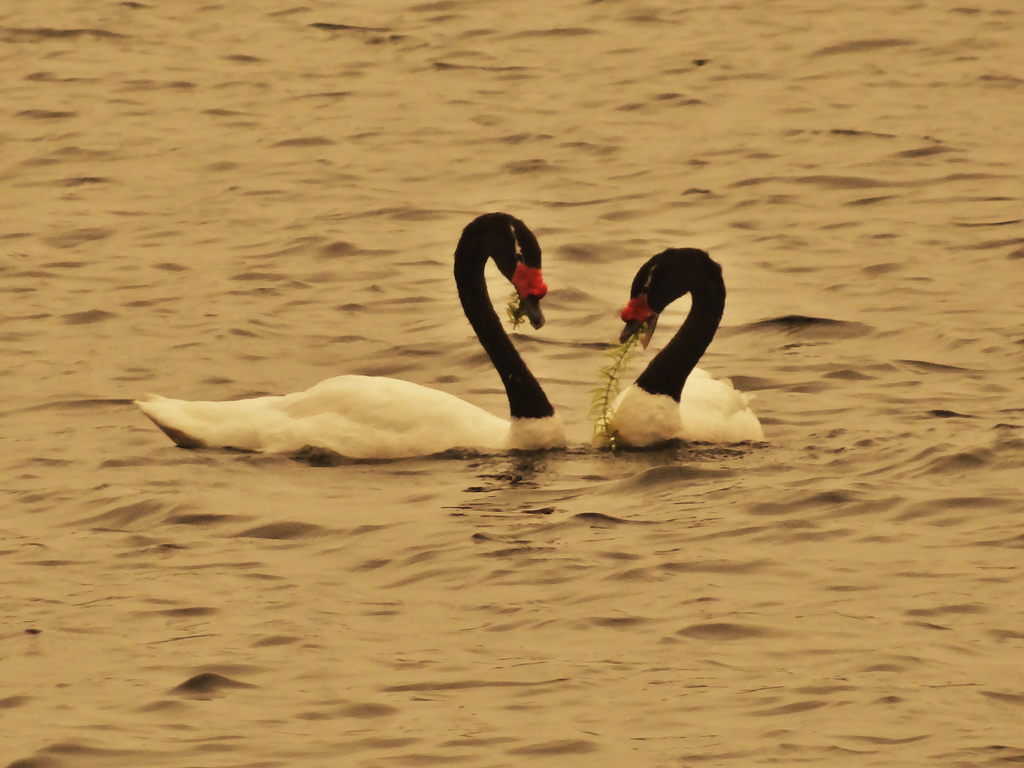

2017-12-20 Laguna San Pedro

-*Fórmulas matemáticas*

Markdown ha heredado el potencial de LaTeX para generar formulas con una tipografía adecuada y elegante. Con estas podemos escribir lo que deseemos. Gracias a esta opción podemos distinguir fotográficamente las variables matemáticas o estadísticas de los objetos o variables en R:

la variable x se asocia al objeto x.

La variable $x$ se asocia al objeto `x`.

La fracción 1 entre n se consigue:

$$\frac{1}{n}$$

$$\left( \frac{1}{n} \right) ^ 2$$

-*Citas y referencias Bibliográficas*

+Primero hay que especificar el archivo bibliográfico que vamos a usar, insertándolo desde los metadatos. cabe escribirlos en el mismo documento, como un inline reference. . Los datos de bibliografía puede usarse multitud de formatos. . Para crear una cita insertamos el identificador del documento precedido de @ . El sistema se encargará de generar el apartado de referencias, y tanto estas como las citas ser realizarón con el formato especificado.

Dentro de un texto como dijo @Perez2010 …

Como se ha demostrado [@Perez2010] …

Dentro de un texto como dijo Perez (2010) utilizar la cabeza y un modo racional de trabajo puede ahorrar muchos dolores de idem.

Como se ha demostrado (Perez 2010) los automatas son un alivio en tareas rutinarias.

*Referencias*

Perez, P. 2010. Este es el título del artículo. Este es el nombre de la revista 6:13-21.